# Self-Driving Car Engineer Nanodegree

## Project: Build a Traffic Sign Recognition Classifier

In this notebook, a template is provided for you to implement your functionality in stages, which is required to successfully complete this project. If additional code is required that cannot be included in the notebook, be sure that the Python code is successfully imported and included in your submission if necessary.

In addition to implementing code, there is a writeup to complete. The writeup should be completed in a separate file, which can be either a markdown file or a pdf document. There is a [write up template](https://github.com/udacity/CarND-Traffic-Sign-Classifier-Project/blob/master/writeup_template.md) that can be used to guide the writing process. Completing the code template and writeup template will cover all of the [rubric points](https://review.udacity.com/#!/rubrics/481/view) for this project.

The [rubric](https://review.udacity.com/#!/rubrics/481/view) contains "Stand Out Suggestions" for enhancing the project beyond the minimum requirements. The stand out suggestions are optional. If you decide to pursue the "stand out suggestions", you can include the code in this Ipython notebook and also discuss the results in the writeup file.

> **Note:** Code and Markdown cells can be executed using the **Shift + Enter** keyboard shortcut. In addition, Markdown cells can be edited by typically double-clicking the cell to enter edit mode.

## Step 0: Load The Data

```python
# Load pickled data
import pickle

# TODO: Fill this in based on where you saved the training and testing data

training_file = "traffic-signs-data/train.p"
validation_file= "traffic-signs-data/valid.p"
testing_file = "traffic-signs-data/test.p"

with open(training_file, mode='rb') as f:
    train = pickle.load(f)
with open(validation_file, mode='rb') as f:
    valid = pickle.load(f)
with open(testing_file, mode='rb') as f:
    test = pickle.load(f)

X_train, y_train = train['features'], train['labels']
X_valid, y_valid = valid['features'], valid['labels']
X_test, y_test = test['features'], test['labels']
```

## Step 1: Dataset Summary & Exploration

The pickled data is a dictionary with 4 key/value pairs:

- `'features'` is a 4D array containing raw pixel data of the traffic sign images, (num examples, width, height, channels).
- `'labels'` is a 1D array containing the label/class id of the traffic sign. The file `signnames.csv` contains id -> name mappings for each id.
- `'sizes'` is a list containing tuples, (width, height) representing the original width and height the image.
- `'coords'` is a list containing tuples, (x1, y1, x2, y2) representing coordinates of a bounding box around the sign in the image. **THESE COORDINATES ASSUME THE ORIGINAL IMAGE. THE PICKLED DATA CONTAINS RESIZED VERSIONS (32 by 32) OF THESE IMAGES**

Complete the basic data summary below. Use python, numpy and/or pandas methods to calculate the data summary rather than hard coding the results. For example, the [pandas shape method](http://pandas.pydata.org/pandas-docs/stable/generated/pandas.DataFrame.shape.html) might be useful for calculating some of the summary results.

### Provide a Basic Summary of the Data Set Using Python, Numpy and/or Pandas

### Import packages first

```python
import pandas as pd
import numpy as np
import tensorflow as tf
```

```python
### Data exploration visualization code goes here.
### Feel free to use as many code cells as needed.
import matplotlib.pyplot as plt
# Visualizations will be shown in the notebook.
%matplotlib inline
#import seaborn as sb
import random
from sklearn.utils import shuffle
```

```python
### Replace each question mark with the appropriate value.
### Use python, pandas or numpy methods rather than hard coding the results

# TODO: Number of training examples
n_train = len(X_train)

# TODO: Number of testing examples.
n_valid = len(X_valid)

# TODO: Number of testing examples.
n_test = len(X_test)

# TODO: What's the shape of an traffic sign image?
image_shape = X_train.shape[1:]

# TODO: How many unique classes/labels there are in the dataset.

n_classes = len(pd.value_counts(y_train).index)

n_classes = len(np.unique(y_train))   #np.unique生成一个元素都是唯一的array

n_classes = len(set(y_train))   #这里也可以使用set，因为set中的元素不重复，所以得到43个元素的set,再求len即可.

print("Number of training examples =", n_train)
print("Number of validation examples =", n_valid)
print("Number of testing examples =", n_test)
print("Image data shape =", image_shape)
print("Number of classes =", n_classes)
```

```
Number of training examples = 34799
Number of validation examples = 4410
Number of testing examples = 12630
Image data shape = (32, 32, 3)
Number of classes = 43
```

```python
#combine all the y label data and see if there is any label which appears in valid/test set but not in train set.
y_total=np.concatenate((y_train,y_valid,y_test))
print ('Total number of examples is: %d'%y_total.shape)
print ('Total number of class is: %d'%len(pd.value_counts(y_train).index))
```

```
Total number of examples is: 51839
Total number of class is: 43
```

### Include an exploratory visualization of the dataset

Visualize the German Traffic Signs Dataset using the pickled file(s). This is open ended, suggestions include: plotting traffic sign images, plotting the count of each sign, etc.

The [Matplotlib](http://matplotlib.org/) [examples](http://matplotlib.org/examples/index.html) and [gallery](http://matplotlib.org/gallery.html) pages are a great resource for doing visualizations in Python.

**NOTE:** It's recommended you start with something simple first. If you wish to do more, come back to it after you've completed the rest of the sections.

```python
exploratory_dic={'train set':n_train,'valid set':n_valid,'test set':n_test}
exploratory_se= pd.Series(exploratory_dic)
exploratory_se
```

```
test set     12630
train set    34799
valid set     4410
dtype: int64
```

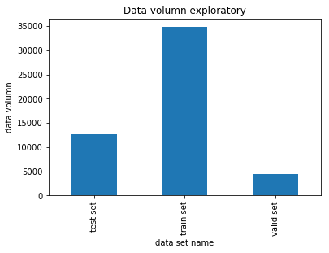

```python
exploratory_se.plot(kind='bar',title='Data volumn exploratory')
plt.xlabel('data set name')
plt.ylabel('data volumn')
```

[figure not shown]

```python
#label distribution exploratory
#we can see the distributions of three data are almost same.
y_train_vis=pd.value_counts(y_train).sort_index()    #value_counts之后sort_index，是按index来排列数据
y_vaild_vis=pd.value_counts(y_valid).sort_index()
y_test_vis=pd.value_counts(y_test).sort_index()
fig,axes=plt.subplots(2,2)
y_train_vis.plot(kind='bar',ax=axes[0][0],figsize=(20,10),title='train set')   #分别放在不同的子figure中
y_vaild_vis.plot(kind='bar',ax=axes[0][1],figsize=(20,10),title='vaild set')
y_vaild_vis.plot(kind='bar',ax=axes[1][0],figsize=(20,10),title='test set')
```

[output not shown]

```python
index = random.randint(0, len(X_train))  #随机取一个int
index=4076   #这里为了显示限速30的标志，所以index设置为4076
image = X_train[index].squeeze()  #由于是x_train中的img是32*32，使用squeeze平铺数据(也可以不用squeeze)
plt.figure(figsize=(1,1))
plt.imshow(image)
print(y_train[index])
```

[output not shown]

```
1
```

#### 计算trainset中count小于1500的数，并存放为array,用于generate fake data

```python
len(y_train_vis[y_train_vis<=1500].index)
```

```
35
```

```python
y_train_vis[y_train_vis<=1500]
```

```
0      180
3     1260
6      360
7     1290
8     1260
9     1320
11    1170
14     690
15     540
16     360
17     990
18    1080
19     180
20     300
21     270
```

[output cut: 21 more lines]

```python
np.array(y_train_vis[y_train_vis<=1500].index,dtype = np.uint8())
```

```
array([ 0,  3,  6,  7,  8,  9, 11, 14, 15, 16, 17, 18, 19, 20, 21, 22, 23,
       24, 25, 26, 27, 28, 29, 30, 31, 32, 33, 34, 35, 36, 37, 39, 40, 41,
       42], dtype=uint8)
```

```python
y_train_fake_class=np.array(y_train_vis[y_train_vis<=1500].index,dtype = np.int32())
```

##### numpy.squeeze usage 用来剔除array中长度为1的轴

```python
x = np.array([[[0], [1], [2]]])
```

```python
x.shape  #1*3*1
```

```
(1, 3, 1)
```

```python
np.squeeze(x) #把括号都去除掉了
```

```
array([0, 1, 2])
```

```python
np.squeeze(x).shape #变成3*1了
```

```
(3,)
```

##### display all the images and labels

set(y_valid) #set排序和去重后的结果，可以看下

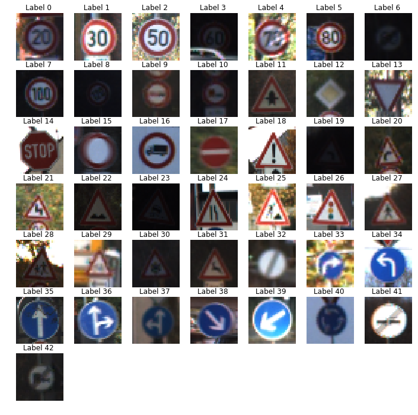

```python
#show the test data images and labels
def display_images_and_labels(images, labels):
    """Display the first image of each label."""
    unique_labels = set(labels)     #set中不会有重复的值,并且会按照值的大小升序排列，共43个lable
    y_valid_se=pd.Series(labels)    #建立y_valid这个series,里边的y是重复的，共30000+条记录
    label_list=[]
    for i in unique_labels:                          #unique_labels就是label中的43个label数字
        for index,label in enumerate(y_valid_se):    #enumerate返回索引index和y_valid_se中的值
            if label==i:                             #当重复的series中的label=不重复的set中值后
                label_list.append(index)             #label_list中存放这个label对应的在series中index
                break                                #由于只保留这个label的第一张图，所以找到后跳出break

    plt.figure(figsize=(12, 12))
    j = 1                                           #这里j是subplot中的子图位置
    for yindex,xindex in enumerate(label_list):     #label_list的index就是class_id,value就是y_test中的index
        image = images[xindex]
        plt.subplot(7, 7,j)  # A grid of 8 rows x 8 columns
        plt.axis('off')
        plt.title("Label {0} ".format(yindex))
        j += 1
        _=plt.imshow(image)

    plt.show()

display_images_and_labels(X_test, y_test)
```

## Step 2: Design and Test a Model Architecture

Design and implement a deep learning model that learns to recognize traffic signs. Train and test your model on the [German Traffic Sign Dataset](http://benchmark.ini.rub.de/?section=gtsrb&subsection=dataset).

The LeNet-5 implementation shown in the classroom at the end of the CNN lesson is a solid starting point. You'll have to change the number of classes and possibly the preprocessing, but aside from that it's plug and play!

With the LeNet-5 solution from the lecture, you should expect a validation set accuracy of about 0.89. To meet specifications, the validation set accuracy will need to be at least 0.93. It is possible to get an even higher accuracy, but 0.93 is the minimum for a successful project submission.

There are various aspects to consider when thinking about this problem:

- Neural network architecture (is the network over or underfitting?)
- Play around preprocessing techniques (normalization, rgb to grayscale, etc)
- Number of examples per label (some have more than others).
- Generate fake data.

Here is an example of a [published baseline model on this problem](http://yann.lecun.com/exdb/publis/pdf/sermanet-ijcnn-11.pdf). It's not required to be familiar with the approach used in the paper but, it's good practice to try to read papers like these.

### Pre-process the Data Set (normalization, grayscale, etc.)

Use the code cell (or multiple code cells, if necessary) to implement the first step of your project.

## using Tensorflow to preprocess the Data Set

### 1.Grayscale

```python
### Preprocess the data here. Preprocessing steps could include normalization, converting to grayscale, etc.
### Feel free to use as many code cells as needed.
### Preprocess the data here. Preprocessing steps could include normalization, converting to grayscale, etc.
### Feel free to use as many code cells as needed.
X_train_gray = tf.image.rgb_to_grayscale(X_train)
img_tf = tf.Variable(X_train_gray)
init = tf.global_variables_initializer()

#Then you can run your graph:
with tf.Session() as sess:
    sess.run(init)
    #im = sess.run(img_tf)
    im=img_tf.eval(session=sess)              #return a narray whose name is 'im'
    print (img_tf.get_shape().as_list())  # [32, 32, 1]
```

```
[34799, 32, 32, 1]
```

```python
np.asarray(im[4076]).ndim   #im is a array
```

```
3
```

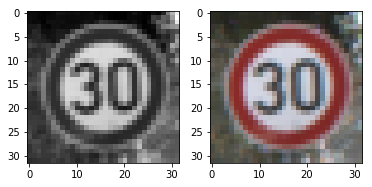

```python
plt.subplot(1, 2,1)
plt.imshow(im[4076].squeeze(), cmap="gray")   #we have to use squeeze() function when it comes to one input channal(32*32*1)
plt.subplot(1, 2,2)
plt.imshow(X_train[4076])
```

```python
X_train.shape,im.shape
```

```
((34799, 32, 32, 3), (34799, 32, 32, 1))
```

### 2.flip right and left randomly(we Cannot apply this to do Augument!!!)

this op doesn't make any sence as flip signs will make it difficult to understand the real meaning of the sign.

```python
#flip_image = tf.image.random_flip_left_right(distorted_image)
#X_train_flip = tf.image.random_flip_left_right(im[3049])
X_train_flip = tf.image.flip_left_right(im[3049])
img_tf = tf.Variable(X_train_flip)
init = tf.global_variables_initializer()
```

```python
#Then you can run your graph:
with tf.Session() as sess:
    sess.run(init)
    #im = sess.run(img_tf)
    im_flip=img_tf.eval(session=sess)              #return a narray whose name is 'im'
    print (img_tf.get_shape().as_list())  # [32, 32, 1]
```

```
[32, 32, 1]
```

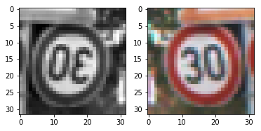

```python
plt.subplot(1, 2,1)
plt.imshow(im_flip.squeeze(), cmap="gray")   #we have to use squeeze() function when it comes to one input channal(32*32*1)
plt.subplot(1, 2,2)
plt.imshow(X_train[3049])
```

### 3.Rotate the sign( we cannot apply rotation as TF only has a function to rotate 90 degree)

however I did find a function in tensorlayer that can achieve this goal. it is add_random_rotation (max_angle=20.0)

### 4.Normalization

```python
#X_train_nor = tf.image.per_image_standardization(X_train[3049])
X_train_nor = tf.image.per_image_standardization(im[3049])
img_tf = tf.Variable(X_train_nor)
init = tf.global_variables_initializer()
```

```python
#Then you can run your graph:
with tf.Session() as sess:
    sess.run(init)
    #im = sess.run(img_tf)
    im_nor=img_tf.eval(session=sess)              #return a narray whose name is 'im'
    print (img_tf.get_shape().as_list())  # [32, 32, 1]
```

```
[32, 32, 1]
```

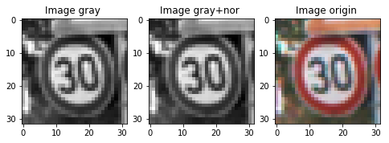

```python
plt.figure(figsize=(8, 8))
plt.subplot(1, 3,1)
plt.imshow(im[3049].squeeze(), cmap="gray")   #we have to use squeeze() function when it comes to one input channal(32*32*1)
plt.title("Image {0} ".format('gray'))
plt.subplot(1, 3,2)
plt.imshow(im_nor.squeeze(), cmap="gray")   #we have to use squeeze() function when it comes to one input channal(32*32*1)
plt.title("Image {0} ".format('gray+nor'))
plt.subplot(1, 3,3)
plt.imshow(X_train[3049])
plt.title("Image {0} ".format('origin'))
```

## Using opencv instand of TF to preform distorting image

```python
#importing some useful packages
import matplotlib.pyplot as plt
import matplotlib.gridspec as gridspec
import cv2

import numpy as np
%matplotlib inline
import matplotlib.image as mpimg
```

### 1.brightness augmentation

```python
def augment_brightness_camera_images(image):        #HSV中的V可以改为HLS中的L
    '''
    随机变换亮度
    Arg:image
    Return:变换过亮度后的image
    '''
    image1 = cv2.cvtColor(image,cv2.COLOR_RGB2HSV)   #先转换成HSV Color space
    random_bright = .25+np.random.uniform()          #浮动随机数0.25
    #print(random_bright)
    image1[:,:,2] = image1[:,:,2]*random_bright     #HSV的V channel乘以随机数0.25产生新的亮度值
    image1 = cv2.cvtColor(image1,cv2.COLOR_HSV2RGB) #再由HSV转换成RGB
    return image1
```

[figure not shown]

```python
plt.figure(figsize=(3, 3))
plt.subplot(1, 2,1)
plt.imshow(X_train[3050])
plt.title('origin')
plt.subplot(1, 2,2)
plt.imshow(augment_brightness_camera_images(X_train[3050]))
plt.title('after-brightness')
```

### 2.transform augmentation(包含了rotation, shear,translate,brightness)

http://www.myexception.cn/image/1958561.html

#### 2.1 rotation 旋转图像

```python
org=X_train[3050]
```

```python
#uniform函数主要是随机产生一个数字，所有可能产生的数字都是同分布的。np.random.uniform(下限,上限,size)
np.random.uniform(20)  #uniform默认是low=0,high=1;这里下限默认是0，上限为20
```

```
9.921166965138742
```

```python
ang_range=20
np.random.uniform(ang_range)-ang_range/2  #这里是随机左右转动10度
```

```
2.881903382210208
```

```python
ang_rot = np.random.uniform(ang_range)-ang_range/2  #见上随机转动左右10度
rows,cols,ch = org.shape      #获得img的rows,cols,channel
```

```python
#第一个参数旋转中心(列/2,行/2)，第二个参数旋转角度(左右10度)，第三个参数：缩放比例
Rot_M = cv2.getRotationMatrix2D((cols/2,rows/2),ang_rot,1)
```

```python
#cv2.warpAffine为仿射函数，可以产生新img.
img = cv2.warpAffine(org,Rot_M,(cols,rows))
```

```python
plt.figure(figsize=(3,3))
plt.subplot(121)
plt.imshow(org)
plt.subplot(122)
plt.imshow(img)
```

[output not shown]

#### 2.2 translation平移，类似旋转，要先产生一个矩阵M（不累述）

#### 2.3 Shear= AffineTransform 仿射变换

```python
np.float32([[5,5],[20,5],[5,20]])
```

```
array([[  5.,   5.],
       [ 20.,   5.],
       [  5.,  20.]], dtype=float32)
```

```python
shear_range=10
```

```python
pts1 = np.float32([[5,5],[20,5],[5,20]])  #原始图片中的三个点的坐标

pt1 = 5+shear_range*np.random.uniform()-shear_range/2    #原图到新图的坐标这个等式得出，原理不明
pt2 = 20+shear_range*np.random.uniform()-shear_range/2

pts2 = np.float32([[pt1,5],[pt2,pt1],[5,pt2]])  #仿射变换后的图片中三个点的坐标

shear_M = cv2.getAffineTransform(pts1,pts2)    #获得仿射变换的矩阵
```

```python
org=X_train[3050]
#cv2.warpAffine为仿射函数，可以产生新img.
img = cv2.warpAffine(org,shear_M,(cols,rows))
```

```python
plt.figure(figsize=(3,3))
plt.subplot(121)
plt.imshow(org)
plt.subplot(122)
plt.imshow(img)
```

[output not shown]

### transform_image函数包含了rotation,shear(Affine),translation,brightness

```python
def transform_image(img,ang_range,shear_range,trans_range,brightness=1,norm=0):
    '''
    This function transforms images to generate new images.
    The function takes in following arguments,
    1- Image
    2- ang_range: Range of angles for rotation
    3- shear_range: Range of values to apply affine transform to
    4- trans_range: Range of values to apply translations over.

    A Random uniform distribution is used to generate different parameters for transformation

    Example:transform_image(X_train[10015],20,10,5,brightness=1)

    '''
    # Rotation  旋转

    ang_rot = np.random.uniform(ang_range)-ang_range/2
    rows,cols,ch = img.shape
    Rot_M = cv2.getRotationMatrix2D((cols/2,rows/2),ang_rot,1)

    # Translation  平移
    tr_x = trans_range*np.random.uniform()-trans_range/2
    tr_y = trans_range*np.random.uniform()-trans_range/2
    Trans_M = np.float32([[1,0,tr_x],[0,1,tr_y]])     #平移矩阵

    # Shear =Affine 仿射变换
    pts1 = np.float32([[5,5],[20,5],[5,20]])

    pt1 = 5+shear_range*np.random.uniform()-shear_range/2
    pt2 = 20+shear_range*np.random.uniform()-shear_range/2

    pts2 = np.float32([[pt1,5],[pt2,pt1],[5,pt2]])

    shear_M = cv2.getAffineTransform(pts1,pts2)

    img = cv2.warpAffine(img,Rot_M,(cols,rows))       #旋转
    img = cv2.warpAffine(img,Trans_M,(cols,rows))     #平移
    img = cv2.warpAffine(img,shear_M,(cols,rows))     #仿射

    #Brightness 亮度变换
    if brightness == 1:
        img = augment_brightness_camera_images(img)

    #这里是resize变换大小功能，可以尝试下

    #image = cv2.cvtColor(image, cv2.COLOR_BGR2YUV)
    #image = image[:,:,0]
    #image = cv2.resize(image, (img_resize,img_resize),interpolation = cv2.INTER_CUBIC)

    #normalization
    if norm==1:
        img_nor=img
        img_nor[:,:,0]=(img[:,:,0]-128.)/128.
        img_nor[:,:,1]=(img[:,:,1]-128.)/128.
        img_nor[:,:,2]=(img[:,:,2]-128.)/128.
        img=img_nor

    return img
```

```python
gridspec.GridSpec  #这个是matplotlib中专门用来画subplot的网格函数
```

```
matplotlib.gridspec.GridSpec
```

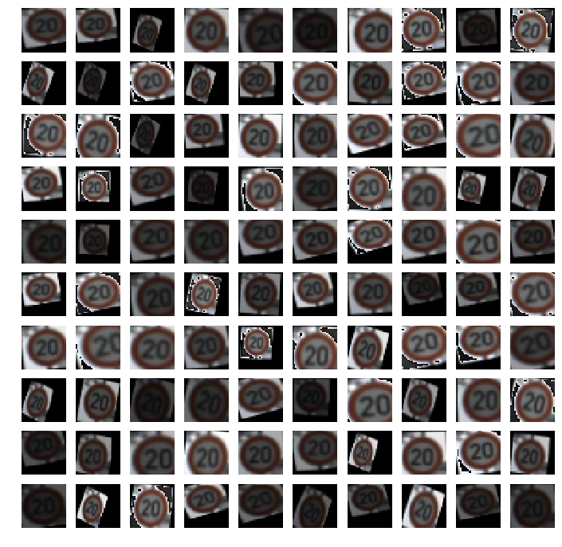

```python
#本段代码中的gs1相关部分都没用，可以注释掉
gs1 = gridspec.GridSpec(10, 10)       #10行10列,这句其实没用
gs1.update(wspace=0.01, hspace=0.02) # set the spacing between axes. 设置grid(subplot)之间的width和height
plt.figure(figsize=(12,12))
plt.imshow(X_train[10015])
for i in range(100):
    ax1 = plt.subplot(gs1[i])       #gs1[i]每一个i都是一个subplot
    ax1.set_xticklabels([])
    ax1.set_yticklabels([])
    ax1.set_aspect('equal')
    #img = transform_image(X_train[10015],20,10,5,brightness=1)    #图像变换
    img = transform_image(X_train[10015],ang_range=20,shear_range=10,trans_range=5,brightness=1)
    plt.subplot(10,10,i+1)          #10行10列,这句关键
    plt.imshow(img)
    plt.axis('off')

plt.show()
```

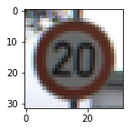

```python
plt.figure(figsize=(2,2))
plt.imshow(X_train[10015])
```

[figure not shown]

```python
# test the norm and transform functions
plt.figure(figsize=(2,2))
img_test=transform_image(X_train.astype(np.float32)[10015],ang_range=20,shear_range=10,trans_range=5,brightness=1,norm=1)
plt.imshow(img_test)
```